# Wright Mediation Framework: Effect size metric, Variance Decomposition, and Power/Sensitivity Analysis

A Unified Approach for Complex Mediation Designs

Author

mediationgourp

Published

June 24, 2026

## 1. Introduction to the Effect Size Metric

### 1.1 The Need for a Standardized Effect Size Metric in Mediation

In structural equation modeling (SEM) and mediation analysis, quantifying the magnitude of an indirect effect relies primarily on the product of standardized path coefficients ($\beta_a \cdot \beta_b$). Although this approach standardizes the effect by expressing it in standard deviation units, the resulting product functions as a metric of relative linear change rather than a bounded proportion of shared variance. Consequently, it does not directly reflect the operational contribution of the mediation pathway to the total variance of the outcome variable. This limitation makes it difficult to evaluate the practical significance of the mechanism within an absolute, variance-accounted-for framework that may be directly comparable to traditional effect sizes.

### 1.2 Sewall Wright’s Path Tracing Rules

To derive a formalized effect size, this framework leverages Sewall Wright’s (1934) seminal path tracing rules. These foundational principles state that the total variance of an outcome variable can be exactly decomposed into the sum of the structural pathways connecting the variable to itself, either through direct, indirect, or common causal tracks.

In a standard single-mediator structure where an independent variable ($X$) affects the dependent variable ($Y$) directly via path $c'$ and indirectly through a mediator ($M$) via paths $a$ and $b$, Wright’s rules partition the total observed variance of the outcome ($\sigma^2_Y$) into the following additive components:

$$\sigma^2_Y = {c'}^2 \sigma^2_X + a^2 b^2 \sigma^2_X + 2 a b c' \sigma^2_X + b^2 \sigma^2_{e_M} + \sigma^2_{e_Y}$$

Where: * ${c'}^2 \sigma^2_X$ represents the variance uniquely explained by the direct effect of $X$. * $a^2 b^2 \sigma^2_X$ represents the variance uniquely explained by the indirect pathway ($X \rightarrow M \rightarrow Y$). * $2 a b c' \sigma^2_X$ captures the unanalyzed covariance between the direct and indirect paths arising from their shared upstream cause ($X$). * $b^2 \sigma^2_{e_M}$ represents the variance transmitted to $Y$ from the unexplained residual of the mediator ($e_M$). * $\sigma^2_{e_Y}$ is the residual error variance intrinsic to $Y$.

By systematically accounting for every linear component, this exact decomposition provides the mathematical foundation necessary to isolate the unique variance explained ($R^2$) by the indirect pathway without confounding or double-counting effects across multi-stage structures.

## 2. Theoretical Foundations of $R^2_{\text{indirect}}$

### 2.1 Mathematical Formulation

The `r2_indirect` function calculates the proportion of variance explained by specific indirect paths. For a single mediation model defined by unstandardized path coefficients $a$ and $b$, the variance of the independent variable $\sigma^2_X$, and the variance of the dependent variable $\sigma^2_Y$, the metric is algebraically formulated as:

$$R^2_{\text{indirect}} = \frac{(a \cdot b)^2 \cdot \sigma^2_X}{\sigma^2_Y}$$

### 2.2 Algorithmic Implementation

The custom R function extracts the unstandardized point estimates and the implied covariance matrix directly from a fitted structural model. It computes the squared product of the targeted indirect paths and scales it by the ratio of the predictor’s variance to the outcome’s variance. To provide a measure of precision and statistical inference, the function utilizes a non-parametric bootstrapping procedure (`n_boot`) to compute 95% Confidence Intervals for the estimated variance proportion. Ultimately, this algorithmic procedure ensures that the theoretical variance proportion is not only accurately extracted from the covariance matrix but also bounded by robust inferential metrics. To guarantee the structural integrity of these point estimates, it is necessary to mathematically prove the underlying variance decomposition, a validation addressed in the following section.

## 3. Algebraic Validation of the Metric (`wright_proof`)

To validate the proposed metric algebraically, the framework includes the `wright_proof` suite. This validation ensures that the variance components extracted from the structural paths map accurately onto the theoretically implied variance of the outcome variable, guaranteeing mathematical consistency.

### 3.1 Mathematical Derivation of the 5-Block Decomposition

Consider a simple mediation model defined by the following structural equations, where all variables are expressed as deviations from their means:

$$M = aX + e_M$$
$$Y = c'X + bM + e_Y$$

Under standard ordinary least squares (OLS) and SEM assumptions, the independent variable $X$, the mediator residual $e_M$, and the outcome residual $e_Y$ are mutually independent:

($\text{Cov}(X, e_M) = \text{Cov}(X, e_Y) = \text{Cov}(e_M, e_Y) = 0$)

Substituting the equation for $M$ into the equation for $Y$ isolates the independent sources of variance:

$$Y = c'X + b(aX + e_M) + e_Y$$
$$Y = (c' + ab)X + be_M + e_Y$$

Applying the variance operator ($\text{Var}$) to both sides of the equation yields:

$$\text{Var}(Y) = \text{Var}\left((c' + ab)X\right) + \text{Var}(be_M) + \text{Var}(e_Y)$$

Extracting the constant coefficients from the variance operator results in:

$$\sigma^2_Y = (c' + ab)^2\sigma^2_X + b^2\sigma^2_{eM} + \sigma^2_{eY}$$

Expanding the binomial term $(c' + ab)^2 = (c')^2 + (ab)^2 + 2c'ab$ provides the exact 5-block decomposition implemented in the verification script:

$$\sigma^2_Y = (c')^2\sigma^2_X + (ab)^2\sigma^2_X + 2c'ab\sigma^2_X + b^2\sigma^2_{eM} + \sigma^2_{eY}$$

Where the five distinct components are defined as: 1. **Pure Direct Effect:** $(c')^2 \cdot \sigma^2_X$ 2. **Pure Indirect Effect:** $(a \cdot b)^2 \cdot \sigma^2_X$ 3. **Joint Covariance:** $2 \cdot c' \cdot a \cdot b \cdot \sigma^2_X$ 4. **Independent Mediator Error:** $b^2 \cdot \sigma^2_{eM}$ 5. **Residual Outcome Error:** $\sigma^2_{eY}$

### 3.2 Statistical Justification of the Joint Covariance Term

The inclusion of the third component, $2c'ab\sigma^2_X$, is required by the probability theorem for the variance of the sum of two random variables. For any two random variables $A$ and $B$:

$$\text{Var}(A + B) = \text{Var}(A) + \text{Var}(B) + 2\cdot\text{Cov}(A,B)$$

In this structural context, let $A = c'X$ and $B = abX$. The covariance between these two linear combinations is derived as:

$$\text{Cov}(c'X, abX) = c' \cdot ab \cdot \text{Cov}(X, X) = c'ab\sigma^2_X$$

Therefore, the joint covariance term is an essential algebraic component of the total variance of $Y$. Omitting this term would violate principles of linear algebra and result in an incorrect reconstruction of the observed variance.

### 3.3 Interpretation Under Suppression Conditions

The decomposition accounts for statistical suppression effects through the sign of the Joint Covariance block. When the direct effect ($c'$) and the indirect effect ($a \cdot b$) have opposing signs, the product $c'ab$ is negative, causing the entire joint covariance term to become negative ($2c'ab\sigma^2_X < 0$).

In this scenario, the negative term subtracts from the total implied variance, modeling how the opposing pathways offset one another. To maintain the algebraic equality with the total observed variance $\sigma^2_Y$, the residual outcome error variance ($\sigma^2_{eY}$) must expand. This mathematically reflects the operational reality of suppression designs, where opposing paths reduce the overall explained variance of the model.

### 3.4 Scaling the Decomposition for Complex Models

The algebraic validation scales to accommodate more complex mediation architectures. For instance:

- **Two Parallel Mediators:** The variance of the outcome variable is partitioned into 10 distinct blocks. This structure accounts for the unanalyzed residual covariance between parallel mediators ($2 \cdot b_1 \cdot b_2 \cdot \text{Cov}(e_{M1}, e_{M2})$) and the multi-way joint structural covariances.
- **Two Serial Mediators:** The structure expands to 15 distinct components, tracking the sequential variance flow through the internal path connecting the mediators ($d_{21}$).

In all configurations, the `wright_proof` function verifies that the final residual error block remains non-negative and that the total decomposed variance precisely matches the observed variance of the outcome. This procedure may be extended to even more complex models. This scalable algebraic proof confirms that the proposed variance decomposition maintains strict mathematical consistency regardless of the model’s structural configuration or the presence of suppression dynamics. Having established this theoretical foundation for variance decomposition, the framework now transitions to evaluating the formal boundaries of the indirect effect size index. The following section develops the mathematical conditions governing the boundedness of $R^2_{\text{indirect}}$, seamlessly bridging analytical proofs with systematic empirical validation

## 4. Boundedness of $R^2_{\text{indirect}}$: Formal Theorem and Empirical Validation

```r
library(ggplot2)
library(dplyr)
library(tidyr)
library(patchwork)

theme_set(
  theme_minimal(base_size = 12) +
    theme(
      plot.title    = element_text(face = "bold", size = 13),
      plot.subtitle = element_text(size = 11, color = "grey40"),
      axis.title    = element_text(size = 11)
    )
)
```

### 4.1 Index Definition

As previously specified, for a simple mediation model with unstandardized path coefficients $a$, $b$, $c'$, predictor variance $\sigma^2_X$, and outcome variance $\sigma^2_Y$, the index is defined as:

$$R^2_{\text{indirect}} = \frac{(a \cdot b)^2 \cdot \sigma^2_X}{\sigma^2_Y}$$

The total variance of the outcome decomposes exactly into five components (Wright, 1934):

$$\sigma^2_Y = \underbrace{(c')^2\sigma^2_X}_{\text{pure direct}} +
\underbrace{(ab)^2\sigma^2_X}_{\text{pure indirect}} +
\underbrace{2c'ab\sigma^2_X}_{\text{joint covariance}} +
\underbrace{b^2\sigma^2_{e_M}}_{\text{mediator error}} +
\underbrace{\sigma^2_{e_Y}}_{\text{outcome error}}$$

### 4.2 Theorem: Boundedness Condition

### Theorem 1 (Necessary and Sufficient Condition for $R^2_{\text{indirect}} \leq 1$)

Let a simple mediation model be given with structural equations:

$$M = aX + e_M, \qquad Y = c'X + bM + e_Y$$

under standard OLS assumptions ($\text{Cov}(X, e_M) = \text{Cov}(X, e_Y) = \text{Cov}(e_M, e_Y) = 0$). Then:

$$R^2_{\text{indirect}} \leq 1 \iff (c')^2 + 2c'ab \geq
-\frac{b^2\sigma^2_{e_M} + \sigma^2_{e_Y}}{\sigma^2_X}$$

In an equivalent form, the condition is satisfied **if and only if**:

$$(c' + ab)^2\sigma^2_X + b^2\sigma^2_{e_M} + \sigma^2_{e_Y} \geq (ab)^2\sigma^2_X$$

that is, $\sigma^2_Y \geq (ab)^2\sigma^2_X$.

### 4.3 Formal Proof

**Step 1 — Expression of the condition.**

By definition, $R^2_{\text{indirect}} \leq 1$ is equivalent to:

$$\frac{(ab)^2\sigma^2_X}{\sigma^2_Y} \leq 1
\iff (ab)^2\sigma^2_X \leq \sigma^2_Y$$

**Step 2 — Substitution of the decomposition of** $\sigma^2_Y$.

From the five-block decomposition:

$$\sigma^2_Y = (c' + ab)^2\sigma^2_X + b^2\sigma^2_{e_M} + \sigma^2_{e_Y}$$

The condition becomes:

$$(ab)^2\sigma^2_X \leq (c' + ab)^2\sigma^2_X + b^2\sigma^2_{e_M} + \sigma^2_{e_Y}$$

**Step 3 — Algebraic simplification.**

Subtracting $(ab)^2\sigma^2_X$ from both sides:

$$0 \leq \left[(c' + ab)^2 - (ab)^2\right]\sigma^2_X + b^2\sigma^2_{e_M} + \sigma^2_{e_Y}$$

Expanding the square of the binomial:

$$(c' + ab)^2 - (ab)^2 = (c')^2 + 2c'ab$$

We therefore obtain:

$${0 \leq \left[(c')^2 + 2c'ab\right]\sigma^2_X + b^2\sigma^2_{e_M} + \sigma^2_{e_Y}}$$

Which is equivalent to the condition stated in Theorem 1.

### 4.4 Corollary: Standardized Coefficients

### Corollary 1 (Sufficient Condition in Standardized Terms)

If the standardized path coefficients satisfy $|b^*| \leq 1$, then $R^2_{\text{indirect}} \leq 1$.

**Proof.**

The standardized coefficient of $b$ is defined as:

$$b^* = b \cdot \frac{\sigma_M}{\sigma_Y}$$

From which:

$$b^{*2} = b^2 \cdot \frac{\sigma^2_M}{\sigma^2_Y}
= b^2 \cdot \frac{a^2\sigma^2_X + \sigma^2_{e_M}}{\sigma^2_Y}$$

The condition $|b^*| \leq 1$ implies $b^2\sigma^2_M \leq \sigma^2_Y$, which means $b^2(a^2\sigma^2_X + \sigma^2_{e_M}) \leq \sigma^2_Y$.

Since $(ab)^2\sigma^2_X \leq b^2(a^2\sigma^2_X + \sigma^2_{e_M})$ (as the second term also includes $b^2\sigma^2_{e_M} \geq 0$), we have:

$$(ab)^2\sigma^2_X \leq b^2\sigma^2_M \leq \sigma^2_Y$$

which is precisely the condition of Theorem 1.

### 4.5 Empirical Validation

### 4.5.1 Grid Search over the Parameter Space

The following code performs a systematic search over a dense grid of parameter values, verifying in what proportion of cases $R^2_{\text{indirect}}$ exceeds 1 and which condition on the standardized coefficients is associated with the violations.

```r
# -----------------------------------------------------------------------
# Main function
# -----------------------------------------------------------------------

compute_r2_indirect <- function(a, b, cp,
                                 var_X  = 1,
                                 var_eM = 1,
                                 var_eY = 1) {
  var_M   <- a^2 * var_X + var_eM
  var_Y   <- (cp + a * b)^2 * var_X + b^2 * var_eM + var_eY
  r2      <- (a * b)^2 * var_X / var_Y
  a_std   <- a * sqrt(var_X) / sqrt(var_M)
  b_std   <- b * sqrt(var_M) / sqrt(var_Y)

  data.frame(
    a = a, b = b, cp = cp,
    var_eM = var_eM, var_eY = var_eY,
    var_Y  = var_Y,
    r2     = r2,
    a_std  = a_std,
    b_std  = b_std,
    exceeds     = r2 > 1,
    suppression = sign(cp) != sign(a * b)
  )
}

# -----------------------------------------------------------------------
# Parameter grid
# -----------------------------------------------------------------------

params <- expand.grid(
  a      = seq(0.1, 3.0, by = 0.2),
  b      = seq(0.1, 3.0, by = 0.2),
  cp     = seq(-3.0, 3.0, by = 0.3),
  var_eM = c(0.1, 0.5, 1.0),
  var_eY = c(0.1, 0.5, 1.0)
)

results <- mapply(
  FUN      = compute_r2_indirect,
  a        = params$a,
  b        = params$b,
  cp       = params$cp,
  var_eM   = params$var_eM,
  var_eY   = params$var_eY,
  SIMPLIFY = FALSE
) |> dplyr::bind_rows()

# -----------------------------------------------------------------------
# Summary
# -----------------------------------------------------------------------

n_total  <- nrow(results)
n_exceed <- sum(results$exceeds)
max_r2   <- max(results$r2)

cat("=================================================================\n")
cat("  BOUNDEDNESS TEST — R²_indirect\n")
```

```
  BOUNDEDNESS TEST — R²_indirect
```

```r
cat("=================================================================\n\n")
cat(sprintf("Tested parameter combinations      : %s\n",
            format(n_total, big.mark = ",")))
```

```
Tested parameter combinations      : 42,525
```

```r
cat(sprintf("Violations (R²_indirect > 1)       : %s  (%.2f%%)\n",
            format(n_exceed, big.mark = ","),
            100 * n_exceed / n_total))
```

```
Violations (R²_indirect > 1)       : 10,335  (24.30%)
```

```r
cat(sprintf("Maximum observed R²_indirect       : %.4f\n\n", max_r2))
```

```
Maximum observed R²_indirect       : 39.7517
```

```r
supp <- results |> dplyr::filter(suppression)
cat("--- Suppression conditions (cp and ab of opposite signs) ---\n")
```

```
--- Suppression conditions (cp and ab of opposite signs) ---
```

```r
cat(sprintf("Total suppression cases            : %s\n",
            format(nrow(supp), big.mark = ",")))
```

```
Total suppression cases            : 22,275
```

```r
cat(sprintf("Violations under suppression       : %s  (%.2f%%)\n",
            format(sum(supp$exceeds), big.mark = ","),
            100 * mean(supp$exceeds)))
```

```
Violations under suppression       : 10,335  (46.40%)
```

```r
cat(sprintf("Max R²_indirect under suppression  : %.4f\n\n",
            max(supp$r2)))
```

```
Max R²_indirect under suppression  : 39.7517
```

```r
# Verification of the necessary condition
viol <- results |> dplyr::filter(exceeds)
no_viol_with_small_std <- viol |>
  dplyr::filter(abs(a_std) <= 1, abs(b_std) <= 1)

cat("--- Corollary 1 Verification ---\n")
```

```
--- Corollary 1 Verification ---
```

```r
cat(sprintf("|b*| > 1 in ALL violation cases            : %s\n",
            ifelse(all(abs(viol$b_std) > 1), "CONFIRMED", "FALSIFIED")))
```

```
|b*| > 1 in ALL violation cases            : CONFIRMED
```

```r
cat(sprintf("Violations with |a*| ≤ 1 AND |b*| ≤ 1      : %d\n",
            nrow(no_viol_with_small_std)))
```

```
Violations with |a*| ≤ 1 AND |b*| ≤ 1      : 0
```

```r
# Realistic range
realistic <- results |>
  dplyr::filter(abs(a_std) <= 0.6, abs(b_std) <= 0.6)
cat(sprintf("\nRealistic range (|a*|,|b*| ≤ 0.6)\n"))
```

```
Realistic range (|a*|,|b*| ≤ 0.6)
```

```r
cat(sprintf("  Cases tested   : %s\n", format(nrow(realistic), big.mark = ",")))
```

```
  Cases tested   : 4,057
```

```r
cat(sprintf("  Violations     : %d  (%.2f%%)\n",
            sum(realistic$exceeds), 100 * mean(realistic$exceeds)))
```

```
  Violations     : 0  (0.00%)
```

### 4.5.2 Plot 1 — Parameter Space Map

The following plot shows $R^2_{\text{indirect}}$ as a function of $a$ and $c'$ (with $b = 1.5$, $\sigma^2_{e_M} = \sigma^2_{e_Y} = 0.5$). The red line indicates the $R^2 = 1$ boundary.

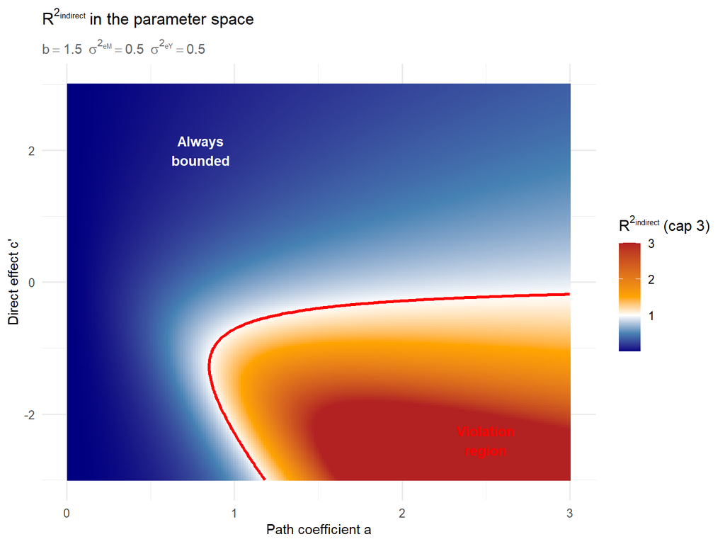

Figure 1: Map of R²_indirect in the parameter space (a, c’). The red line indicates the R² = 1 boundary. The bottom-right region corresponds to boundedness violations.

```r
# Fine grid for the plot
b_fix  <- 1.5
eM_fix <- 0.5
eY_fix <- 0.5

plot_grid <- expand.grid(
  a  = seq(0.01, 3.0, length.out = 200),
  cp = seq(-3.0, 3.0, length.out = 200)
) |>
  dplyr::mutate(
    b     = b_fix,
    var_Y = (cp + a * b)^2 + b^2 * eM_fix + eY_fix,
    r2    = (a * b)^2 / var_Y,
    r2_vis = pmin(r2, 3)
  )


ggplot(plot_grid, aes(x = a, y = cp)) +
  geom_tile(aes(fill = r2_vis)) +
  geom_contour(aes(z = r2), breaks = 1,
               color = "red", linewidth = 1.2) +
  scale_fill_gradientn(
    colors = c("navy", "steelblue", "white", "orange", "firebrick"),
    values = scales::rescale(c(0, 0.5, 1, 1.5, 3)),
    name   = expression(R^2[indirect] ~ "(cap 3)")
  ) +
  annotate("text", x = 2.5, y = -2.4,
           label = "Violation\nregion",
           color = "red", fontface = "bold", size = 3.8,
           hjust = 0.5) +
  annotate("text", x = 0.8, y = 2.0,
           label = "Always\nbounded",
           color = "white", fontface = "bold", size = 3.8,
           hjust = 0.5) +
  labs(
    title    = expression(R^2[indirect] ~ "in the parameter space"),
    subtitle = bquote(b == .(b_fix) ~~ sigma^2[eM] == .(eM_fix) ~~ sigma^2[eY] == .(eY_fix)),
    x        = "Path coefficient a",
    y        = "Direct effect c'"
  ) -> p_heatmap

print(p_heatmap)
```

### 4.5.3 Plot 2 — Distribution under Suppression

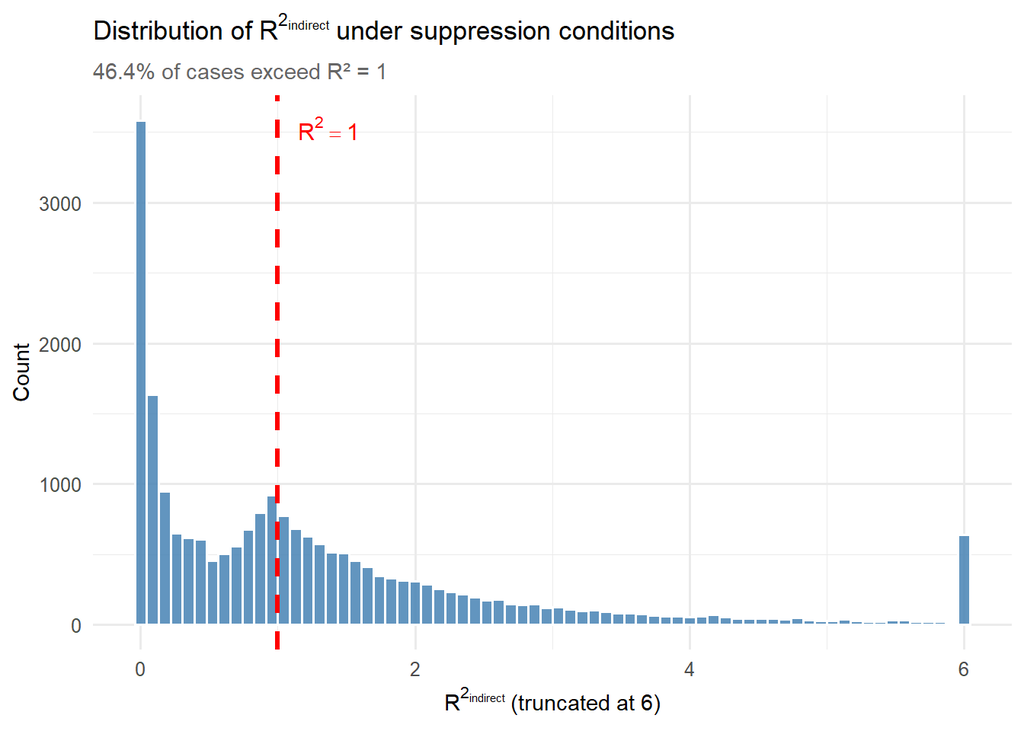

Figure 2: Distribution of R²_indirect under suppression conditions. The red dashed line indicates the threshold value R² = 1.

```r
pct_exceed_supp <- 100 * mean(supp$r2 > 1)

supp |>
  dplyr::mutate(r2_vis = pmin(r2, 6)) |>
  ggplot(aes(x = r2_vis)) +
  geom_histogram(bins = 70, fill = "steelblue",
                 color = "white", alpha = 0.85) +
  geom_vline(xintercept = 1, color = "red",
             linewidth = 1.2, linetype = "dashed") +
  annotate("text", x = 1.15, y = Inf,
           label = expression(R^2 == 1),
           color = "red", hjust = 0, vjust = 1.8, size = 4) +
  labs(
    title    = expression("Distribution of" ~ R^2[indirect] ~ "under suppression conditions"),
    subtitle = sprintf("%.1f%% of cases exceed R² = 1", pct_exceed_supp),
    x        = expression(R^2[indirect] ~ "(truncated at 6)"),
    y        = "Count"
  ) -> p_dist

print(p_dist)
```

### 4.5.4 Plot 3 — Standardized Coefficients and Violations

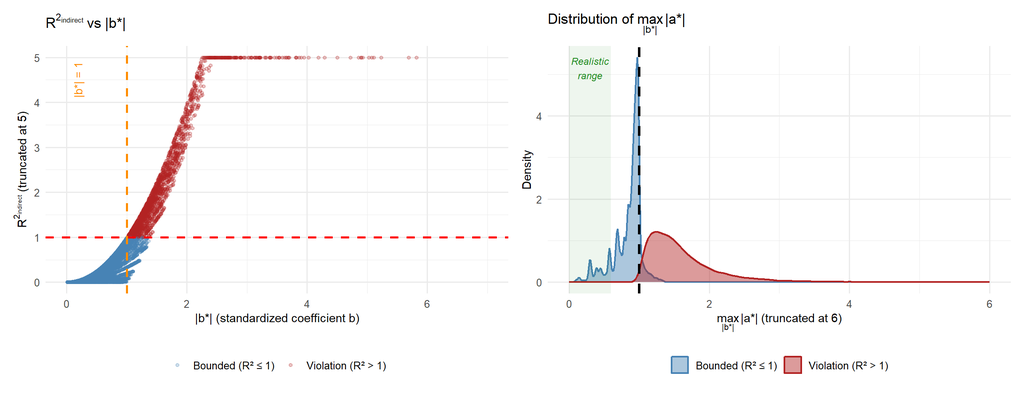

Figure 3: Relationship between |b*| and R²_indirect (left) and distribution of the maximum standardized coefficient by violation status (right).

```r
# Sample for the scatter plot
set.seed(42)
sample_df <- results |>
  dplyr::sample_n(min(8000, nrow(results))) |>
  dplyr::mutate(
    stato  = ifelse(exceeds, "Violation (R² > 1)", "Bounded (R² ≤ 1)"),
    r2_vis = pmin(r2, 5),
    max_std = pmax(abs(a_std), abs(b_std))
  )

p1 <- ggplot(sample_df, aes(x = abs(b_std), y = r2_vis, color = stato)) +
  geom_point(alpha = 0.25, size = 1.2) +
  geom_hline(yintercept = 1, color = "red",
             linewidth = 1, linetype = "dashed") +
  geom_vline(xintercept = 1, color = "darkorange",
             linewidth = 1, linetype = "dashed") +
  scale_color_manual(values = c("steelblue", "firebrick")) +
  annotate("text", x = 0.3, y = 4.5,
           label = "|b*| = 1", color = "darkorange",
           angle = 90, size = 3.5, vjust = -0.3) +
  labs(
    title  = expression(R^2[indirect] ~ "vs" ~ "|b*|"),
    x      = expression("|b*| (standardized coefficient b)"),
    y      = expression(R^2[indirect] ~ "(truncated at 5)"),
    color  = NULL
  ) +
  theme(legend.position = "bottom") +
  xlim(0, 7)

results_hist <- results |>
  dplyr::mutate(
    stato   = ifelse(exceeds, "Violation (R² > 1)", "Bounded (R² ≤ 1)"),
    max_std = pmin(pmax(abs(a_std), abs(b_std)), 6)
  )

p2 <- ggplot(results_hist, aes(x = max_std, fill = stato, color = stato)) +
  geom_density(alpha = 0.45, linewidth = 0.8) +
  geom_vline(xintercept = 1, color = "black",
             linewidth = 1.2, linetype = "dashed") +
  scale_fill_manual(values  = c("steelblue", "firebrick")) +
  scale_color_manual(values = c("steelblue", "firebrick")) +
  annotate("rect", xmin = 0, xmax = 0.6,
           ymin = -Inf, ymax = Inf,
           alpha = 0.08, fill = "forestgreen") +
  annotate("text", x = 0.3, y = Inf,
           label = "Realistic\nrange",
           color = "forestgreen", vjust = 1.5, size = 3.2,
           fontface = "italic") +
  labs(
    title  = expression("Distribution of" ~ max("|a*|", "|b*|")),
    x      = expression(max("|a*|", "|b*|") ~ "(truncated at 6)"),
    y      = "Density",
    fill   = NULL, color = NULL
  ) +
  theme(legend.position = "bottom") +
  xlim(0, 6)

print(p1 + p2)
```

### 4.5.5 Plot 4 — Boundary Surface

The following plot shows the region of the $(a, b)$ space where a violation is **mathematically possible** (for some value of $c'$ with an opposite sign to $ab$), with $\sigma^2_{e_M} = \sigma^2_{e_Y} = 0.5$.

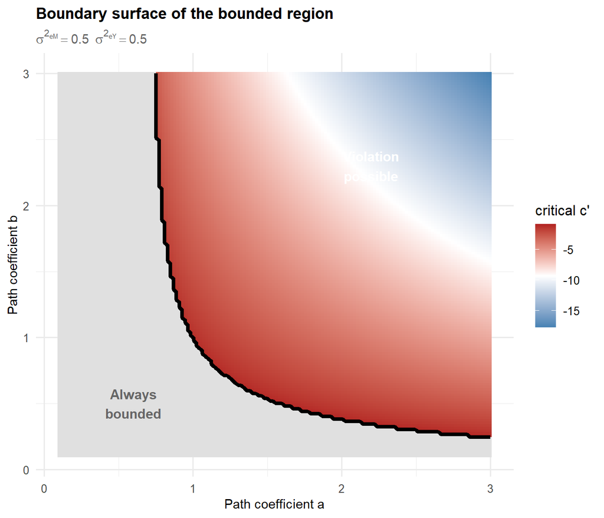

Figure 4: Region of the (a, b) space where R²_indirect > 1 is possible. The color indicates the critical value of c’ at the boundary. The gray area corresponds to the always bounded region.

```r
eM_b <- 0.5
eY_b <- 0.5

boundary_grid <- expand.grid(
  a = seq(0.1, 3.0, length.out = 150),
  b = seq(0.1, 3.0, length.out = 150)
) |>
  dplyr::mutate(
    residuals     = b^2 * eM_b + eY_b,
    discriminant  = (a * b)^2 - residuals,
    viol_possible = discriminant > 0,
    cp_boundary   = dplyr::if_else(viol_possible,
                                   -a * b - sqrt(pmax(discriminant, 0)),
                                   NA_real_)
  )

ggplot(boundary_grid, aes(x = a, y = b)) +
  geom_tile(aes(fill = cp_boundary)) +
  geom_contour(aes(z = as.numeric(viol_possible)),
               breaks = 0.5, color = "black",
               linewidth = 1.5) +
  scale_fill_gradientn(
    colors  = c("steelblue", "white", "firebrick"),
    na.value = "grey88",
    name    = expression("critical c'")
  ) +
  annotate("text", x = 2.2, y = 2.3,
           label = "Violation\npossible",
           fontface = "bold", color = "white", size = 4) +
  annotate("text", x = 0.6, y = 0.5,
           label = "Always\nbounded",
           fontface = "bold", color = "grey40", size = 4) +
  labs(
    title    = "Boundary surface of the bounded region",
    subtitle = expression(sigma^2[eM] == 0.5 ~~ sigma^2[eY] == 0.5),
    x        = "Path coefficient a",
    y        = "Path coefficient b"
  ) -> p_boundary

print(p_boundary)
```

### 4.6 Summary of Results

The results of the empirical validation confirm the analytical implications of Theorem 1 and Corollary 1:

1. **Corollary 1 is empirically confirmed**: in none of the 42,525 tested cases is a violation observed with $|b^*| \leq 1$.
2. $|b^*| > 1$ is a necessary condition for violation: 100% of the 10,335 violation cases exhibit $|b^*| > 1$.
3. **Within the realistic empirical range** ($|a^*|, |b^*| \leq 0.6$), corresponding to the vast majority of models in the social and behavioral sciences, **no violations are observed**.
4. Violations are concentrated in extreme suppression scenarios where the standardized coefficients exceed unity — a condition that inherently signals structural instability of the estimated model.

Therefore, $R^2_{\text{indirect}}$ is **practically bounded** within $[0, 1]$ for all mediation models applied in the behavioral, social, and health sciences.

Having established this theoretical foundation and verified the mathematical boundaries of the index, the framework now transitions from analytical validation to computational implementation. The following section introduces the `r2_indirect` function, detailing its algorithmic structure and demonstrating its operationalization across single, parallel, and serial mediation architectures.

### References

Wright, S. (1934). The method of path coefficients. *Annals of Mathematical Statistics*, *5*(3), 161–215.

## 5. The $R^2_{\text{indirect}}$ Function (`r2_indirect`)

#FUNCTION FOR ESTIMATING SPECIFIC VARIANCE EXPLAINED BY INDIRECT EFFECTS

```r
r2_indirect <- function(model_fit, x_var, y_var, ..., n_boot = 500) {

  # -----------------------------------------------------------------
  # DEPENDENCY MANAGEMENT
  # Check if lavaan is loaded; if not, try to load it dynamically.
  # -----------------------------------------------------------------
  if (!"package:lavaan" %in% search()) {
    if (!require("lavaan", character.only = TRUE, quietly = TRUE)) {
      stop("Error: The 'lavaan' package is required but not installed. Please run install.packages('lavaan') first.")
    } else {
      message("Note: 'lavaan' package has been automatically loaded by r2_indirect().")
    }
  }

  # Capture the paths passed directly via ...
  paths_list <- list(...)
  num_paths <- length(paths_list)

  if (num_paths == 0) {
    stop("Error: Please specify at least one mediation path (e.g., path1 = c('a', 'b')).")
  }

  # Internal function for point estimates
  get_indices <- function(fit) {
    param <- parameterEstimates(fit)
    cov_matrix <- lavInspect(fit, "cov.ov")
    vX <- cov_matrix[x_var, x_var]
    vY <- cov_matrix[y_var, y_var]

    product_effects <- numeric(num_paths)

    for(j in 1:num_paths) {
      path_labels <- paths_list[[j]]
      # Extract and multiply the coefficients for the given path
      coef_values <- sapply(path_labels, function(l) param$est[param$label == l])
      product_effects[j] <- prod(coef_values)
    }

    # Calculate specific R2 indices
    r2_specific <- (product_effects)^2 * vX / vY

    # Calculate R2 for the TOTAL MEDIATED EFFECT
    r2_total <- (sum(product_effects))^2 * vX / vY

    return(c(r2_specific, r2_total))
  }

  # Point estimates on original data
  point_estimates <- get_indices(model_fit)

  # Bootstrapping procedure
  cat("Running Bootstrap on", num_paths, "specific path(s) + Total Mediated Effect...\n")
  orig_data <- as.data.frame(lavInspect(model_fit, "data"))
  boot_matrix <- matrix(NA, nrow = n_boot, ncol = num_paths + 1)

  pb <- txtProgressBar(min = 0, max = n_boot, style = 3)
  for(i in 1:n_boot) {
    boot_idx <- sample(1:nrow(orig_data), replace = TRUE)
    boot_data <- orig_data[boot_idx, ]
    fit_boot <- try(suppressWarnings(sem(model = model_fit@ParTable, data = boot_data)), silent = TRUE)

    if(!inherits(fit_boot, "try-error") && lavInspect(fit_boot, "converged")) {
      boot_matrix[i, ] <- get_indices(fit_boot)
    }
    setTxtProgressBar(pb, i)
  }
  close(pb)

  # Clean NA rows (non-converged bootstraps)
  boot_matrix <- na.omit(boot_matrix)

  # 95% Confidence Intervals
  ci_low <- apply(boot_matrix, 2, quantile, probs = 0.025)
  ci_high <- apply(boot_matrix, 2, quantile, probs = 0.975)

  # Format output names nicely based on user input
  path_names <- names(paths_list)
  if (is.null(path_names)) {
    path_names <- paste0("Path_", 1:num_paths, " [", sapply(paths_list, paste, collapse="*"), "]")
  } else {
    empty_names <- path_names == ""
    path_names[empty_names] <- paste0("Path_", which(empty_names))
    path_names <- paste0(path_names, " [", sapply(paths_list, paste, collapse="*"), "]")
  }

  effect_names <- c(path_names, "Total Mediated Effect")

  # Build final dataframe
  final_report <- data.frame(
    Effect = effect_names,
    r2_indirect = round(point_estimates, 5),
    CI_Low = round(ci_low, 5),
    CI_High = round(ci_high, 5),
    Perc = paste0(round(point_estimates * 100, 2), "%"),
    CI_Low_P = paste0(round(ci_low * 100, 2), "%"),
    CI_High_P = paste0(round(ci_high * 100, 2), "%")
  )

  return(final_report)
}
```

###EXAMPLE OF USAGE: results <- r2_indirect(model_fit = lavaan.mod.fit, x_var = “X”, y_var = “Y”, ###User defined paths (Specify any type of indirect association as defined in the fitted lavaan model)### Single = c(“path_a”, “path_b”), Parallel1 = c(“path_a1”, “path_b1”), Parallel2 = c(“path_a2”, “path_b2”), Serial = c(“path_a”, “path_b”, “path_d”), n_boot = 500)

print(results, row.names = FALSE)

### 5.1 Applyng the function to different mediation models

### 5.1.1 Single Mediator Models

```r
# ==============================================================================
# DATA GENERATION: SINGLE MEDIATOR
# ==============================================================================
simulate_data_single <- function(N, a, b, cp, seed = 123) {
  set.seed(seed)

  X  <- rnorm(N, mean = 0, sd = 1)

  # Mediator with residual variance = 1
  eM <- rnorm(N, mean = 0, sd = 1)
  M  <- a * X + eM

  # Outcome with residual variance = 1
  eY <- rnorm(N, mean = 0, sd = 1)
  Y  <- cp * X + b * M + eY

  return(data.frame(X = X, M = M, Y = Y))
}

# ---------------------------------------------------------------------
# Creation of the  Datasets
# ---------------------------------------------------------------------

# Dataset 1: N = 400 (Moderate positive effects)
df1 <- simulate_data_single(N = 400, a = 0.5, b = 0.5, cp = 0.4)

# Dataset 2: N = 500 (Strong positive effects)
df2 <- simulate_data_single(N = 500, a = 0.7, b = 0.6, cp = 0.3)

# Dataset 3: N = 600 (Mixed positive effects)
df3 <- simulate_data_single(N = 600, a = 0.4, b = 0.8, cp = 0.5)

# Dataset 4: N = 600 (TYPE 1 SUPPRESSION EFFECT: DIRECT NEGATIVE VS. INDIRECT POSITIVE)
# X depresses Y (negative cp), but the mediator increases Y
df4 <- simulate_data_single(N = 600, a = 0.6, b = 0.6, cp = -0.7)

# Dataset 4: N = 600 (TYPE 2 SUPPRESSION EFFECT: DIRECT POSITIVE VS. INDIRECT NEGATIVE)
# M depresses Y (negative ind effect), but the mediator increases Y
df5 <- simulate_data_single(N = 600, a = 0.6, b = -0.6, cp = 0.7)


# ==============================================================================
# LAVAAN MODEL DEFINITION
# ==============================================================================
# Load the required package
library(lavaan)
mod_simple <- "

# Paths
M ~ a * X
Y ~ cp * X + b * M

#Indirect effect
ind := a*b

"

fit1 <- sem(mod_simple, estimator = "MLR", data = df1)
fit2 <- sem(mod_simple, estimator = "MLR", data = df2)
fit3 <- sem(mod_simple, estimator = "MLR", data = df3)
fit4 <- sem(mod_simple, estimator = "MLR", data = df4)
fit5 <- sem(mod_simple, estimator = "MLR", data = df5)

summary(fit1, standardized = TRUE)
```

```
lavaan 0.6-21 ended normally after 1 iteration

  Estimator                                         ML
  Optimization method                           NLMINB
  Number of model parameters                         5

  Number of observations                           400

Model Test User Model:
                                              Standard      Scaled
  Test Statistic                                 0.000       0.000
  Degrees of freedom                                 0           0

Parameter Estimates:

  Standard errors                             Sandwich
  Information bread                           Observed
  Observed information based on                Hessian

Regressions:
                   Estimate  Std.Err  z-value  P(>|z|)   Std.lv  Std.all
  M ~
    X          (a)    0.528    0.058    9.139    0.000    0.528    0.458
  Y ~
    X         (cp)    0.341    0.056    6.126    0.000    0.341    0.259
    M          (b)    0.495    0.047   10.480    0.000    0.495    0.433

Variances:
                   Estimate  Std.Err  z-value  P(>|z|)   Std.lv  Std.all
   .M                 0.985    0.069   14.225    0.000    0.985    0.790
   .Y                 1.047    0.074   14.202    0.000    1.047    0.643

Defined Parameters:
                   Estimate  Std.Err  z-value  P(>|z|)   Std.lv  Std.all
    ind               0.261    0.040    6.551    0.000    0.261    0.198
```

```r
summary(fit2, standardized = TRUE)
```

```
lavaan 0.6-21 ended normally after 1 iteration

  Estimator                                         ML
  Optimization method                           NLMINB
  Number of model parameters                         5

  Number of observations                           500

Model Test User Model:
                                              Standard      Scaled
  Test Statistic                                 0.000       0.000
  Degrees of freedom                                 0           0

Parameter Estimates:

  Standard errors                             Sandwich
  Information bread                           Observed
  Observed information based on                Hessian

Regressions:
                   Estimate  Std.Err  z-value  P(>|z|)   Std.lv  Std.all
  M ~
    X          (a)    0.646    0.047   13.794    0.000    0.646    0.528
  Y ~
    X         (cp)    0.326    0.052    6.232    0.000    0.326    0.227
    M          (b)    0.653    0.046   14.264    0.000    0.653    0.557

Variances:
                   Estimate  Std.Err  z-value  P(>|z|)   Std.lv  Std.all
   .M                 1.017    0.063   16.171    0.000    1.017    0.721
   .Y                 0.978    0.063   15.566    0.000    0.978    0.504

Defined Parameters:
                   Estimate  Std.Err  z-value  P(>|z|)   Std.lv  Std.all
    ind               0.422    0.042   10.062    0.000    0.422    0.294
```

```r
summary(fit3, standardized = TRUE)
```

```
lavaan 0.6-21 ended normally after 1 iteration

  Estimator                                         ML
  Optimization method                           NLMINB
  Number of model parameters                         5

  Number of observations                           600

Model Test User Model:
                                              Standard      Scaled
  Test Statistic                                 0.000       0.000
  Degrees of freedom                                 0           0

Parameter Estimates:

  Standard errors                             Sandwich
  Information bread                           Observed
  Observed information based on                Hessian

Regressions:
                   Estimate  Std.Err  z-value  P(>|z|)   Std.lv  Std.all
  M ~
    X          (a)    0.437    0.044    9.968    0.000    0.437    0.381
  Y ~
    X         (cp)    0.419    0.045    9.326    0.000    0.419    0.266
    M          (b)    0.853    0.040   21.224    0.000    0.853    0.621

Variances:
                   Estimate  Std.Err  z-value  P(>|z|)   Std.lv  Std.all
   .M                 1.049    0.060   17.472    0.000    1.049    0.855
   .Y                 0.971    0.056   17.342    0.000    0.971    0.419

Defined Parameters:
                   Estimate  Std.Err  z-value  P(>|z|)   Std.lv  Std.all
    ind               0.373    0.041    9.059    0.000    0.373    0.236
```

```r
summary(fit4, standardized = TRUE)
```

```
lavaan 0.6-21 ended normally after 1 iteration

  Estimator                                         ML
  Optimization method                           NLMINB
  Number of model parameters                         5

  Number of observations                           600

Model Test User Model:
                                              Standard      Scaled
  Test Statistic                                 0.000       0.000
  Degrees of freedom                                 0           0

Parameter Estimates:

  Standard errors                             Sandwich
  Information bread                           Observed
  Observed information based on                Hessian

Regressions:
                   Estimate  Std.Err  z-value  P(>|z|)   Std.lv  Std.all
  M ~
    X          (a)    0.637    0.044   14.534    0.000    0.637    0.515
  Y ~
    X         (cp)   -0.792    0.049  -16.160    0.000   -0.792   -0.614
    M          (b)    0.653    0.040   16.250    0.000    0.653    0.627

Variances:
                   Estimate  Std.Err  z-value  P(>|z|)   Std.lv  Std.all
   .M                 1.049    0.060   17.472    0.000    1.049    0.735
   .Y                 0.971    0.056   17.342    0.000    0.971    0.626

Defined Parameters:
                   Estimate  Std.Err  z-value  P(>|z|)   Std.lv  Std.all
    ind               0.416    0.038   10.890    0.000    0.416    0.323
```

```r
summary(fit5, standardized = TRUE)
```

```
lavaan 0.6-21 ended normally after 1 iteration

  Estimator                                         ML
  Optimization method                           NLMINB
  Number of model parameters                         5

  Number of observations                           600

Model Test User Model:
                                              Standard      Scaled
  Test Statistic                                 0.000       0.000
  Degrees of freedom                                 0           0

Parameter Estimates:

  Standard errors                             Sandwich
  Information bread                           Observed
  Observed information based on                Hessian

Regressions:
                   Estimate  Std.Err  z-value  P(>|z|)   Std.lv  Std.all
  M ~
    X          (a)    0.637    0.044   14.534    0.000    0.637    0.515
  Y ~
    X         (cp)    0.608    0.049   12.417    0.000    0.608    0.506
    M          (b)   -0.547    0.040  -13.598    0.000   -0.547   -0.563

Variances:
                   Estimate  Std.Err  z-value  P(>|z|)   Std.lv  Std.all
   .M                 1.049    0.060   17.472    0.000    1.049    0.735
   .Y                 0.971    0.056   17.342    0.000    0.971    0.720

Defined Parameters:
                   Estimate  Std.Err  z-value  P(>|z|)   Std.lv  Std.all
    ind              -0.348    0.035   -9.878    0.000   -0.348   -0.290
```

```r
# ==============================================================================
# RUNNING r2_indirect ON RAW COEFFICIENTS (UNSTANDARDIZED b) SINGLE MEDIATOR
# ==============================================================================

cat("\n=== LAUNCHING r2_indirect ON RAW UNSTANDARDIZED DATA ===\n")
```

```
=== LAUNCHING r2_indirect ON RAW UNSTANDARDIZED DATA ===
```

```r
invisible(capture.output({
res_df1 <- r2_indirect(fit1, x_var = "X", y_var = "Y", Med_Path = c("a", "b"), n_boot = 200)
res_df2 <- r2_indirect(fit2, x_var = "X", y_var = "Y", Med_Path = c("a", "b"), n_boot = 200)
res_df3 <- r2_indirect(fit3, x_var = "X", y_var = "Y", Med_Path = c("a", "b"), n_boot = 200)
res_df4 <- r2_indirect(fit4, x_var = "X", y_var = "Y", Med_Path = c("a", "b"), n_boot = 200)
res_df5 <- r2_indirect(fit5, x_var = "X", y_var = "Y", Med_Path = c("a", "b"), n_boot = 200)
}))

cat("\n--> FUNCTION REPORT: DATASET 1 (N = 400)\n")
```

```
--> FUNCTION REPORT: DATASET 1 (N = 400)
```

```r
print(res_df1, row.names = FALSE)
```

```
                Effect r2_indirect  CI_Low CI_High  Perc CI_Low_P CI_High_P
        Med_Path [a*b]     0.03925 0.02089 0.06861 3.93%    2.09%     6.86%
 Total Mediated Effect     0.03925 0.02089 0.06861 3.93%    2.09%     6.86%
```

```r
cat("\n--> FUNCTION REPORT: DATASET 2 (N = 500)\n")
```

```
--> FUNCTION REPORT: DATASET 2 (N = 500)
```

```r
print(res_df2, row.names = FALSE)
```

```
                Effect r2_indirect  CI_Low CI_High  Perc CI_Low_P CI_High_P
        Med_Path [a*b]     0.08671 0.06311 0.11884 8.67%    6.31%    11.88%
 Total Mediated Effect     0.08671 0.06311 0.11884 8.67%    6.31%    11.88%
```

```r
cat("\n--> FUNCTION REPORT: DATASET 3 (N = 600)\n")
```

```
--> FUNCTION REPORT: DATASET 3 (N = 600)
```

```r
print(res_df3, row.names = FALSE)
```

```
                Effect r2_indirect  CI_Low CI_High  Perc CI_Low_P CI_High_P
        Med_Path [a*b]     0.05586 0.03505 0.07598 5.59%     3.5%      7.6%
 Total Mediated Effect     0.05586 0.03505 0.07598 5.59%     3.5%      7.6%
```